# Wearing positions

Author

Johannes Zauner

# Preface

This is a work-in-progress descriptive analysis of the `AkuffoEtAl2025` dataset.

# Influence of wearing positions

```r
#time zone of Kumasi
tz = "Africa/Accra"
#coordinates for Kumasi
coordinates <- c(6.6750074282377385, -1.572643823555129)
#regex to extract participant Id and wearing position
# pattern <- "[A-Z]+_S[0-9]{3}_[hcw]"
#regex to extract participant Id
pattern <- "[A-Z]+_S[0-9]{3}"

country_colors <- c(
  Sweden     = "#88CCEE",  # Sky blue
  Spain      = "#CC6677",  # Coral red
  Germany    = "#DDCC77",  # Mustard yellow
  Netherlands= "#117733",  # Dark green
  Turkey     = "#332288",  # Indigo
  Ghana      = "#AA4499",  # Purple-pink
  Costa_Rica = "#44AA99"   # Teal
)

#path to participants
path_part1 <- "../data/raw/individual"

#path to actlumus data sans wearing position
path_part2 <- "/continuous/actlumus_"


#getting all subfolders
folders <- dir(path_part1)

#wearing positions
wearing_position <- c("chest", "wrist", "head")

#creating complete folder names
paths <-
  wearing_position |>
  map(\(x) glue("{path_part1}/{folders}{path_part2}{x}")) |>
  list_c()

#collecting file names
files <- list.files(paths, pattern = "[0-9]\\.txt$", full.names = TRUE)
pattern <- "[A-Z]+_S[0-9]{3}_[chw]"
```

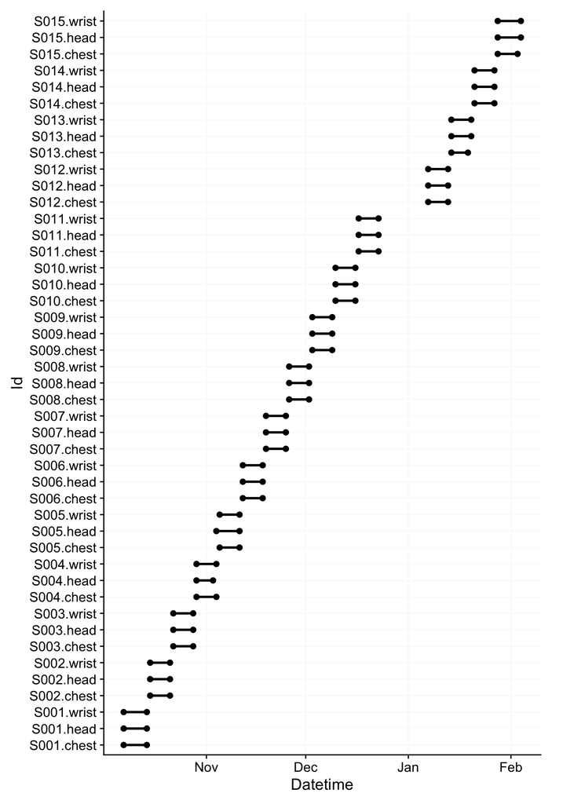

```r
#optionally load prepared data (comment out the import and the next code chunk)
data_cleaned <- read_csv(file = "../data/cleaned/light_all_positions.csv")
data_cleaned |> group_by(Id = interaction(Id, position, lex.order = TRUE)) |> gg_overview()
```

```r
# data <- import$ActLumus(files, tz, auto.id = pattern)
```

Next we apply the cleaning steps as above and remove days with more than 50% missing data. We also remove (for now) unnecessary columns to speed up computation. We also remove data points above 120000 lx.

```r
# data_cleaned <-
# data |>
#   select(Id, Datetime, MEDI, LIGHT) |>
#   aggregate_Datetime() |> #remove irregular data
#   gap_handler(full.days = TRUE) |> #remove implicit gaps
#   add_clusters(MEDI > 2000 & MEDI < 30000,
#                cluster.duration = "20 secs",
#                duration.type = "max") |>
  # mutate(
    # MEDI = ifelse(!is.na(state), lag(MEDI, 2), MEDI),
    # MEDI = ifelse(MEDI > 120000, NA, MEDI)
         # )
#
# data_cleaned <-
#   data_cleaned |>
#   remove_partial_data(MEDI, by.date = TRUE, threshold.missing = "12 hours")
```

Further, we separate the site, participant Id, and wearing position into separate columns.

```r
# data_cleaned <-
#   data_cleaned |>
#     separate_wider_delim(
#       Id, delim = "_", names = c("site", "Id", "position")
#       ) |>
#     mutate(position =
#              factor(position,
#                     levels = c("h", "c", "w"),
#                     labels = c("head", "chest", "wrist")),
#            Id = factor(Id)
#            )
#
# #save the cleaned data
# write_csv(data_cleaned, file = "../data/cleaned/light_all_positions.csv")
```

Let’s look at a sample participant for all three wearing positions. Black indicates all wearing positions, with each wearing position superimposed in color.

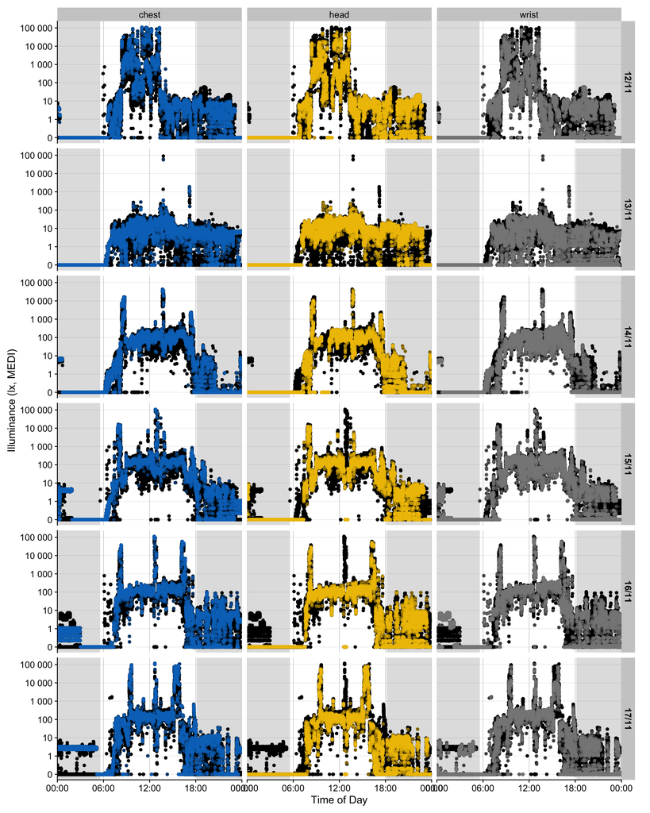

```r
plot <-
data_cleaned |>
  filter(Id == "S006") |>
  gg_day(aes_col = position,
         alpha = 0.5,
         facetting = FALSE, x.axis.breaks = hms::hms(hours = seq(0, 24, by = 6))) |>
  gg_photoperiod(coordinates) +
  facet_grid(rows = vars(Day.data), cols = vars(position)) +
  geom_point(data = \(x) select(x, -position)) +
  guides(color = "none")
plot$layers <- c(plot$layers[1:2], plot$layers[4], plot$layers[3])
plot
```

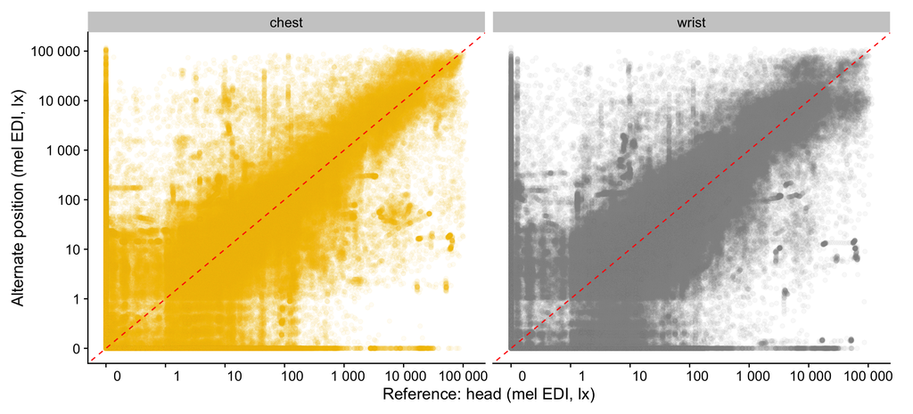

```r
breaks <- c(0, 10^(0:5))
colors <- ggsci::pal_jco()(3) |> set_names(c("head", "chest", "wrist"))

label <- function(x) format(x,
      scientific = FALSE, big.mark = " ")
data_cleaned |>
  pivot_wider(id_cols = c(Id, Datetime), names_from = position, values_from = MEDI) |>
  pivot_longer(cols = c(chest, wrist), names_to = "comparison") |>
  # slice_sample(n = 100) |>
  ggplot(aes(x=head, y = value)) +
  geom_point(alpha = 0.05, aes(col = comparison)) +
  geom_abline(slope = 1, intercept = 0, col = "red", linetype = "dashed") +
  facet_wrap(~comparison) +
  scale_color_manual(values = colors)+
  scale_x_continuous(trans = "symlog", breaks = breaks,
                     labels = label) +
  scale_y_continuous(trans = "symlog", breaks = breaks, labels = label) +
  guides(color = "none") +
  labs(y = "Alternate position (mel EDI, lx)",
       x = "Reference: head (mel EDI, lx)") +
  theme_cowplot() +
  theme(plot.margin = margin(l = 10, b = 10, t = 10, r = 20))
```

## Error: light exposure time series - linear scale

For a comparison, we use the `head` position as reference and show Bland-Altman plots. The resulting angular shapes are simply due to the [symlog](https://tscnlab.github.io/LightLogR/reference/symlog_trans.html) scaling.

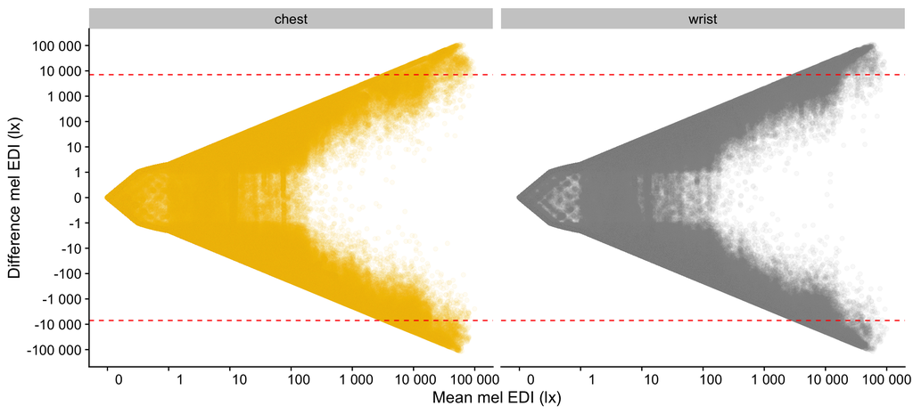

```r
data_widened <-
data_cleaned |>
  pivot_wider(id_cols = c(Id, Datetime), names_from = position, values_from = MEDI) |>
  pivot_longer(cols = c(chest, wrist), names_to = "comparison") |>
  drop_na(head, value)

data_widened |>
  ggplot(
    aes(x = (head + value)/2,
        y = (head - value),
        col = comparison)
    ) +
  geom_point(alpha = 0.05) +
  map(c(-1,1),\(x) {
  geom_hline(aes(yintercept = x*1.96*sd(head-value)),
             col = "red", linetype = "dashed")
    } )+
  facet_wrap(~comparison) +
  scale_color_manual(values = colors)+
  scale_x_continuous(trans = "symlog", breaks = breaks,
                     labels = label) +
  scale_y_continuous(trans = "symlog", breaks = c(-10^(5:0), 0, 10^(0:5)),
                     labels = label) +
  theme_cowplot() +
  guides(color = "none") +
  labs(x = "Mean mel EDI (lx)",
       y = "Difference mel EDI (lx)")
```

Based on these results - there are similar deviations for both wearing positions, and both exceed the confidence interval (CI) at around 2000-3000 lx mel EDI

## Error: light exposure time series - log scale

This section repeats the analysis above, but on a logarithmic scale appropriate for zero-inflated data.

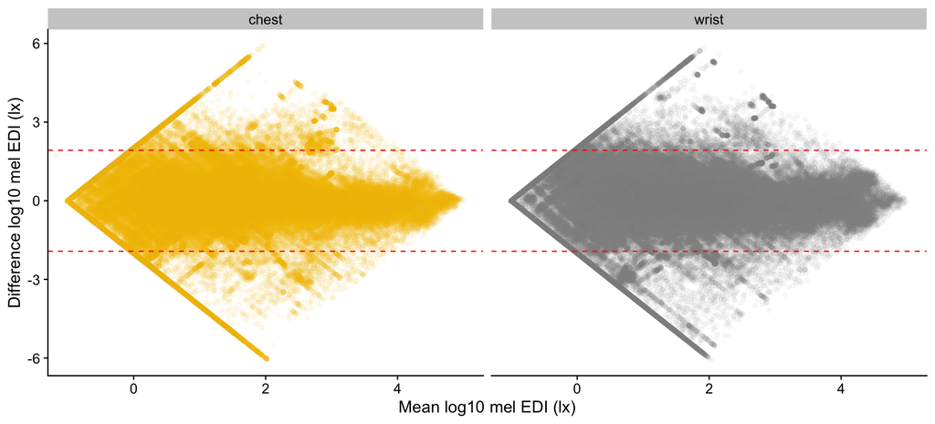

```r
data_widened |>
  mutate(across(c(head, value), log_zero_inflated)) |>
  ggplot(
    aes(x = (head + value)/2,
        y = (head - value),
        col = comparison)
    ) +
  geom_point(alpha = 0.05) +
  map(c(-1,1),\(x) {
  geom_hline(aes(yintercept = x*1.96*sd(head-value)),
             col = "red", linetype = "dashed")
    } )+
  facet_wrap(~comparison) +
  scale_color_manual(values = colors)+
  theme_cowplot() +
  guides(color = "none") +
  labs(x = "Mean log10 mel EDI (lx)",
       y = "Difference log10 mel EDI (lx)")
```

```r
ggsave("../output/figures/Figure_2.png", width = 11, height = 5)
```

We can see that on a logarithmic scale, most data points are within the CI. There are many instances, where the eye-level position has zero-lx readings, but the other position does not (negative diagonal) or vice versa (positive diagonal).

Because the data have not yet been cleaned for non-wear time, these instances can be more numerous.

## Calculating metrics

In the next steps, several metrics are calculated for the different wearing positions. These can be compared with one another to assess the differences on a by-participant and by-day level.

```r
#convenience function for converting datetime to time to double
datetime_2_numeric <- function(x) {
  x |>
    mutate(
      across(
        where(is.POSIXct),
        \(x) x |> hms::as_hms() %>% as.numeric()
      )
    )
}
```

```r
metrics <-
  data_cleaned |>
  add_Date_col() |>
  group_by(Id, Date, position) |>
        summarize(
          duration_above_threshold(
            MEDI, Datetime, "above", 10, na.rm = TRUE, as.df = TRUE),
          duration_above_threshold(
            MEDI, Datetime, "above", 250, na.rm = TRUE, as.df = TRUE),
          duration_above_threshold(
            MEDI, Datetime, "above", 1000, na.rm = TRUE, as.df = TRUE),
          period_above_threshold(
            MEDI, Datetime, "above", 10, na.rm = TRUE, as.df = TRUE),
          period_above_threshold(
            MEDI, Datetime, "above", 250, na.rm = TRUE, as.df = TRUE),
          period_above_threshold(
            MEDI, Datetime, "above", 1000, na.rm = TRUE, as.df = TRUE),
          pulses_above_threshold(
            MEDI, Datetime, threshold = 250, na.rm = TRUE, as.df = TRUE
          )|>
            datetime_2_numeric(),
          pulses_above_threshold(
            MEDI, Datetime, threshold = 1000, na.rm = TRUE, as.df = TRUE
          )|>
            datetime_2_numeric(),
          bright_dark_period(
                  MEDI |> log_zero_inflated(),
                  Datetime, "brightest", "10 hours",
                  as.df = TRUE, na.rm = TRUE
                  ) %>%
            datetime_2_numeric(),
          bright_dark_period(
                  MEDI |> log_zero_inflated(),
                  Datetime, "darkest", "5 hours", as.df = TRUE,
                  loop = TRUE, na.rm = TRUE
                  ) %>%
            datetime_2_numeric(),
          intradaily_variability(MEDI, Datetime, na.rm = TRUE, as.df = TRUE),
          timing_above_threshold(
              MEDI, Datetime, "above", 10, as.df = TRUE) |>
            datetime_2_numeric(),
          timing_above_threshold(MEDI, Datetime, "above", 250, as.df = TRUE) |>
            datetime_2_numeric(),
          frequency_crossing_threshold(MEDI, 250, na.rm = TRUE, as.df = TRUE),
          timing_above_threshold(
              MEDI, Datetime, "above", 1000, as.df = TRUE) |>
            datetime_2_numeric(),
          barroso_lighting_metrics(
            MEDI, Datetime, loop = TRUE, na.rm = TRUE, as.df = TRUE
             ),
          centroidLE(MEDI, Datetime, na.rm = TRUE, as.df = TRUE) |>
            datetime_2_numeric(),
          disparity_index(MEDI, TRUE, TRUE),
          midpointCE(MEDI, Datetime, TRUE, TRUE)|>
            datetime_2_numeric(),
          mean_MEDI = mean(MEDI |> log_zero_inflated(), na.rm = TRUE),
          nvRD = nvRD(MEDI, LIGHT, Datetime) |> mean(na.rm = TRUE),
          dose(MEDI, Datetime, na.rm = TRUE, as.df = TRUE),
          .groups = "drop",
        ) %>%
        mutate(across(where(is.duration), as.numeric)) %>%
        pivot_longer(cols = -c(Id, Date, position), names_to = "metric")

metrics2 <-
  data_cleaned |>
  group_by(Id, position) |>
  remove_partial_data(MEDI, by.date = TRUE, threshold.missing = "1 hour") |>
  add_Date_col() |>
        summarize(
            interdaily_stability(MEDI |> log_zero_inflated(),
                                 Datetime, na.rm = TRUE, as.df = TRUE),
          ) |>
  pivot_longer(cols = -c(Id, position), names_to = "metric")


#combine metrics
metrics_combined <-
        bind_rows(
          metrics,
          metrics2
          )

families <- c(rep("Time above threshold", 3),
              rep("Period above threshold", 3),
              rep("Pulses above threshold", 14),
              rep("L10", 4),
              rep("M5", 4),
              "Intradaily variability",
              rep("Timing above threshold", 6),
              "Frequency crossing threshold",
              rep("Timing above threshold", 3),
              rep("Barroso", 7),
              "Centroid of light exposure",
              "Disparity index",
              "Midpoint cumulative exposure",
              "Mean (log) mel EDI",
              "Mean nvRD",
              "Light dose",
              "Interdaily stability"
              )

#general cleaning
metrics_combined <-
metrics_combined |>
  mutate(Date = replace_na(Date, as_date("2024-09-01")),
         position = factor(position, levels = c("head", "chest", "wrist")),
         Id = factor(Id),
         Date = factor(Date)) |>
  nest(data = -c(metric)) |>
  mutate(family = families, .before = metric)
```

## Visualizing metrics

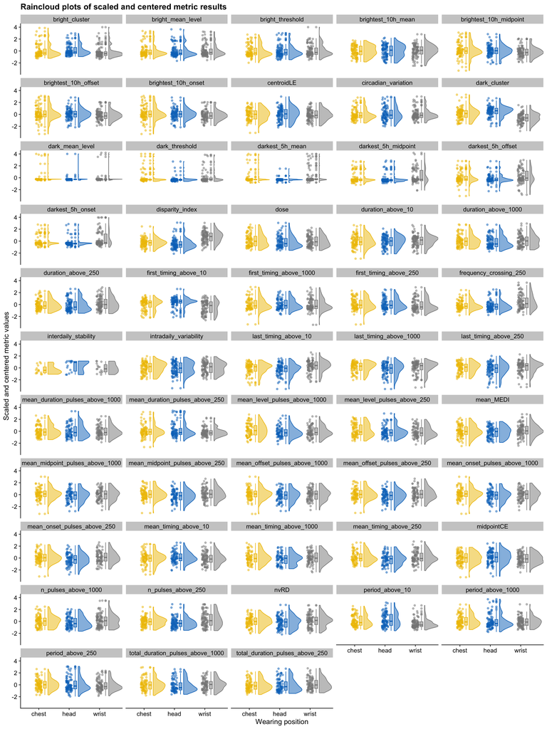

```r
metrics_combined |>
  unnest(data) |>
  group_by(Id, metric) |>
  mutate(
    position = fct_relevel(position, c("chest", "head", "wrist")),
    value = base::scale(value)) |>
  # filter(metric == "bright_cluster") |>
  ggplot(aes(x=position, y = value)) +
  # geom_line(aes(group = interaction(Id, Date)), alpha = 0.1) +
  geom_jitter(aes(col = position), height = 0,
              width = 0.1, alpha = 0.5) +
  geom_boxplot(aes(col = position, fill = position), alpha = 0.5,
               width = 0.1,
              position = position_nudge(x = +0.2)) +
  geom_violinhalf(aes(x = position, y = value,
                   col = position, fill = position),
              position = position_nudge(x = +0.3),
                inherit.aes = FALSE, alpha = 0.5) +
  scale_color_manual(values = colors) +
  scale_fill_manual(values = colors) +
  facet_wrap(~metric, ncol = 5) +
  guides(col = "none", fill = "none") +
  labs(y = "Scaled and centered metric values",
       x = "Wearing position",
       title = "Raincloud plots of scaled and centered metric results") +
  theme_cowplot()
```

```r
ggsave("../output/figures/Figure_3.pdf", width = 15, height = 20)
```

## Testing differences

We test differences with a linear mixed-effect model, where the value of a metric depends upon the wearing position, and varies within a participant and also per day. Some models fail to converge - these will have a fallback formula with less complexity, not considering the date. For `interdaily stability`, a single metric is calculated per participant and wearing position. Thus, this model needs to drop the random effect of day. Additionally, the random slope of wearing position within participants has to be dropped, otherwise the number of parameters to be estimated would be equal the measurement observations.

```r
formula_metric <- value ~ position + (position|Id) + (1|Date)
formula_fallback <- value ~ position + (position|Id)
formula_is <- value ~ position + (1|Id)

#mixed effect analysis and extraction of core metrics
do_the_thing <- function(data, formula) {

  data <-
  data |>
  pivot_wider(names_from = position, values_from = value) |>
  drop_na() |>
  pivot_longer(c(head, chest, wrist), names_to = "position") |>
  mutate(position = factor(position, c("head", "chest", "wrist")))


model <- lmer(formula, data)
did_not_converge <-
  model@optinfo$conv$lme4$messages |>
  str_detect("Model failed to converge") |>
  isTRUE()

if(did_not_converge) {
  model <- lmer(formula_fallback, data)
}

model_summary <-
model |>
  tidy() |>
  mutate(rel_estimate = estimate/estimate[term == "(Intercept)"])

total_var <-
model_summary |>
  filter(str_detect(term, "sd_")) |>
  summarize(tot = sum(estimate^2)) |>
  pull(tot)

ICC <-
  model_summary |>
  filter(str_detect(term, "sd_")) |>
  reframe(sd = str_c(group, ": ", term) |>
            str_replace("sd__", "") |>
            str_replace("position", "head to ") |>
            str_replace("\\(Intercept\\)", "head"),
          sd_coef = rel_estimate,
          ICC = estimate^2/total_var)

effect_summary <-
  model_summary |>
  filter(effect == "fixed") |>
    mutate(term =
             term |>
             str_replace("\\(Intercept\\)", "head") |>
            str_replace("position", "head to "),
           significant = p.value <= 0.05
    ) |>
    select(term, estimate, rel_estimate, p.value, significant)

model_stats <- tibble(
  error_chest = effect_summary[2, 3][[1]],
  signif_chest = effect_summary[2, 5][[1]],
  error_wrist = effect_summary[3, 3][[1]],
  signif_wrist = effect_summary[3, 5][[1]],
  Id_sd = ICC[ICC$sd == "Id: head",]$sd_coef,
  Id_contrib = ICC[ICC$sd == "Id: head",]$ICC,
  chest_sd = if("Id: head to chest" %in% ICC$sd) ICC[ICC$sd == "Id: head to chest",]$sd_coef else NA_real_,
  chest_contrib = if("Id: head to chest" %in% ICC$sd) ICC[ICC$sd == "Id: head to chest",]$ICC else NA_real_,
  wrist_sd = if("Id: head to wrist" %in% ICC$sd) ICC[ICC$sd == "Id: head to wrist",]$sd_coef else NA_real_,
  wrist_contrib = if("Id: head to wrist" %in% ICC$sd) ICC[ICC$sd == "Id: head to wrist",]$ICC else NA_real_,
  Date_sd = if("Date: head" %in% ICC$sd) ICC[ICC$sd == "Date: head",]$sd_coef else NA_real_,
  Date_contrib = if("Date: head" %in% ICC$sd) ICC[ICC$sd == "Date: head",]$ICC else NA_real_,
  Residual_sd = ICC[ICC$sd == "Residual: Observation",]$sd_coef,
  Residual_contrib = ICC[ICC$sd == "Residual: Observation",]$ICC,
  plot = list(ggplot(data) + geom_histogram(aes(x=value)) + facet_wrap(~position)),
  formula = c(formula_metric),
  data = list(data),
  model = list(model),
  model_summary = list(model_summary),
  ICC = list(ICC),
  effect_summary = list(effect_summary)
)

model_stats

}

metric_results <-
  metrics_combined |>
    mutate(formula = list(formula_metric)) |>
    filter(metric != "interdaily_stability") |>
    rowwise() |>
    mutate(do_the_thing(data = data, formula_metric))

metric_results <-
metric_results |>
  rbind(
tibble(family = "Interdaily_stability", metric = "interdaily_stability",
       do_the_thing(data = metrics_combined[53,]$data[[1]], formula_is)
)
)
```

## Summarizing & Visualizing metric differences

The following overview summarizes measurement errors of both `chest` and `wrist` wearing positions, and groups them into whether they show a significant difference from the `head` position. Simplified model structures, as described above, will be shown by missing random effects in the Intraclass correlation (`ICC`) and standard deviations (`SD`).

Summary of significant and non-significant differences in metrics

**Reference level: head**; random intercepts for Id and Date, random slopes for wearing position

Metric

Mean error

Standard deviation (SD)

Boxplot

Intraclass correlation (ICC)

Chest

Wrist

Id

Chest<sup>1</sup>

Wrist<sup>1</sup>

Date<sup>1</sup>

Residual

Id

Chest<sup>1</sup>

Wrist<sup>1</sup>

Date<sup>1</sup>

Residual

Grand minimum (abs)

1%

0%

0%

1%

1%

3%

6%

0%

0%

0%

6%

10%

Grand median (abs)

4%

5%

14%

15%

12%

39%

34%

11%

6%

8%

40%

26%

Grand maximum (abs)

524%

619%

283%

1,445%

1,742%

2,936%

3,254%

69%

20%

35%

75%

68%

None differ significantly from head:

Median (abs)

3%

4%

18%

17%

17%

41%

31%

13%

7%

11%

38%

26%

Period above threshold

period above 250

−9%

−21%

82%

41%

64%

56%

59%

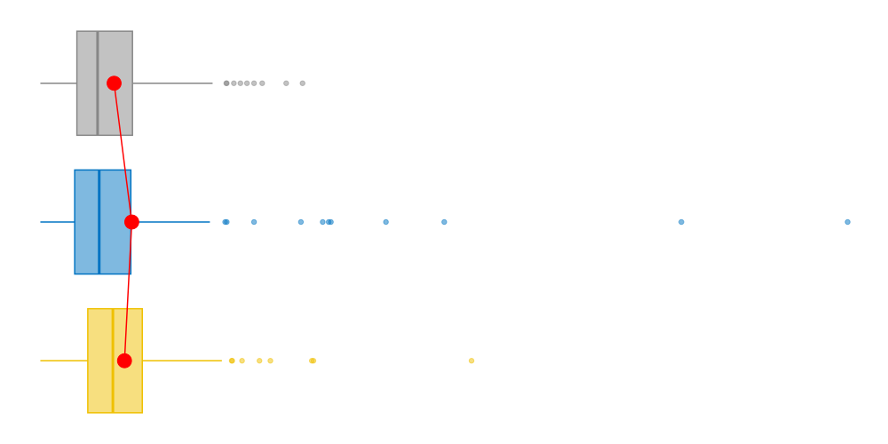

35%

9%

21%

17%

18%

Pulses above threshold

mean duration pulses above 250

−7%

−23%

43%

25%

30%

48%

53%

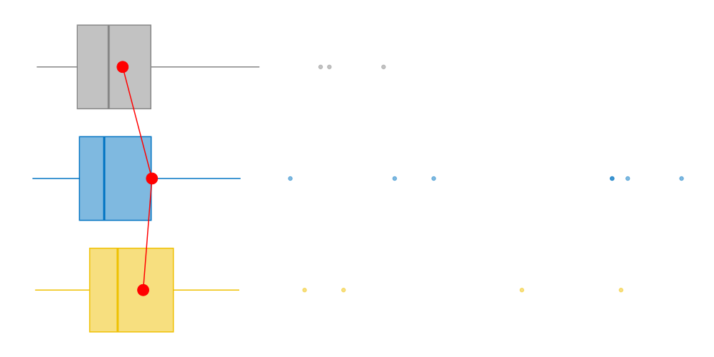

22%

7%

11%

27%

33%

Barroso

bright threshold

−18%

−4%

95%

63%

64%

96%

78%

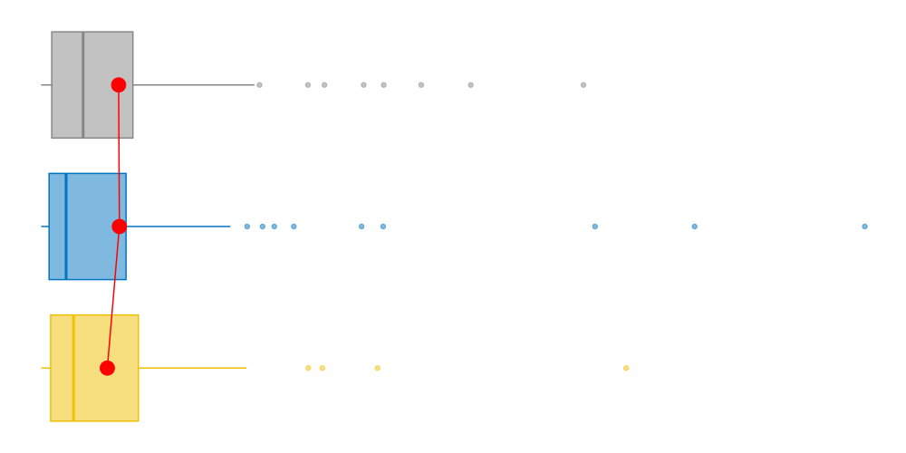

28%

12%

13%

28%

19%

Interdaily_stability

interdaily stability

−8%

−5%

21%

—

—

—

14%

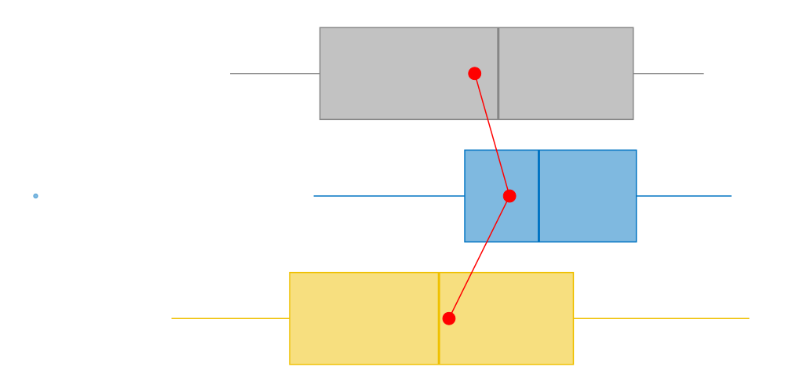

69%

—

—

—

31%

M5

darkest 5h mean

−5%

−7%

0%

−5%

−10%

−13%

−17%

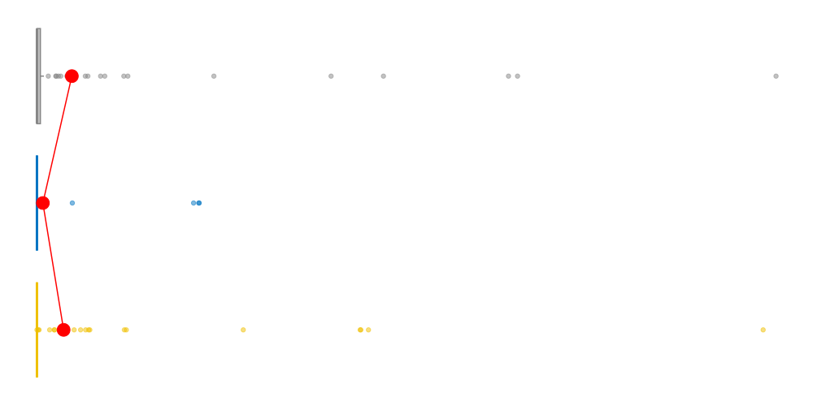

0%

5%

17%

30%

48%

Barroso

bright mean level

−10%

−1%

92%

80%

60%

159%

108%

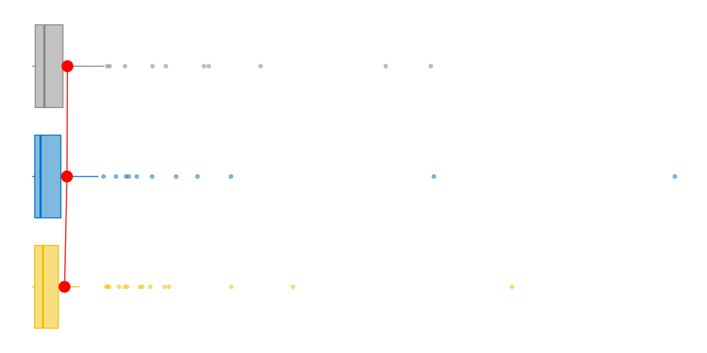

15%

12%

6%

45%

21%

Period above threshold

period above 1000

2%

−9%

46%

29%

38%

57%

83%

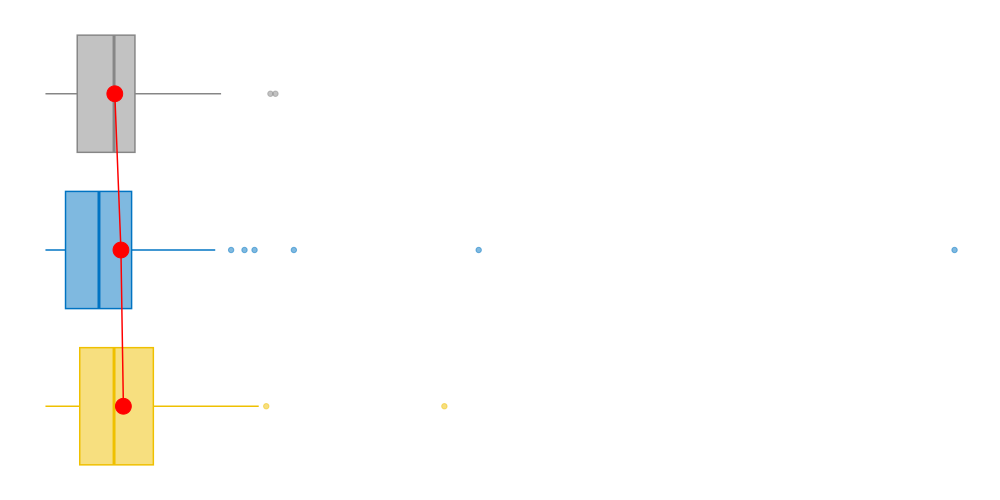

15%

6%

10%

22%

47%

Midpoint cumulative exposure

midpointCE

−3%

−3%

6%

4%

4%

14%

9%

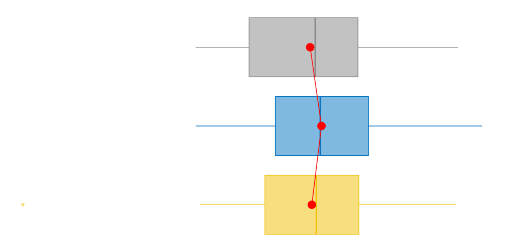

10%

4%

5%

55%

25%

Barroso

circadian variation

−3%

0%

9%

31%

33%

53%

44%

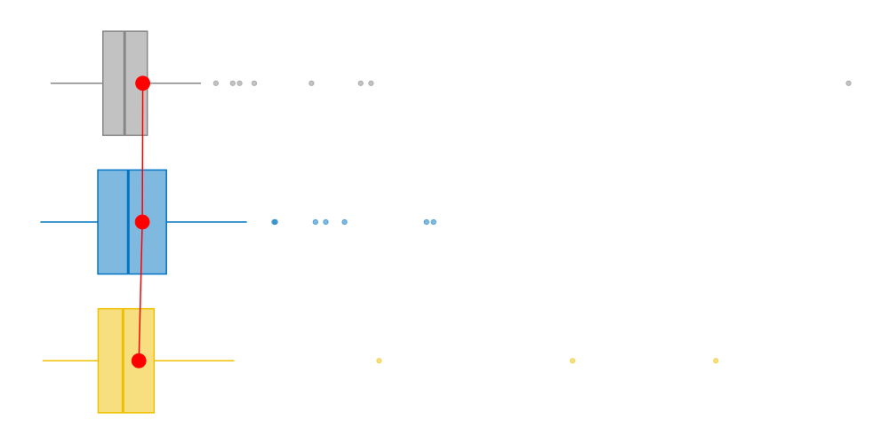

1%

14%

16%

41%

28%

Centroid of light exposure

centroidLE

−1%

−1%

3%

3%

4%

12%

6%

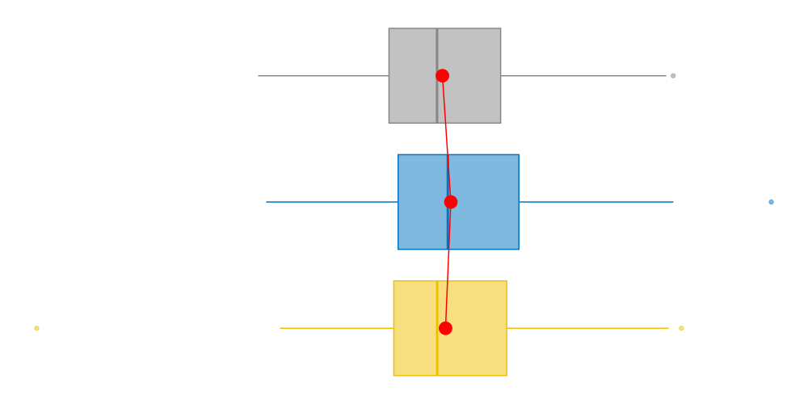

5%

5%

6%

64%

20%

Barroso

bright cluster

−4%

3%

162%

17%

1%

173%

143%

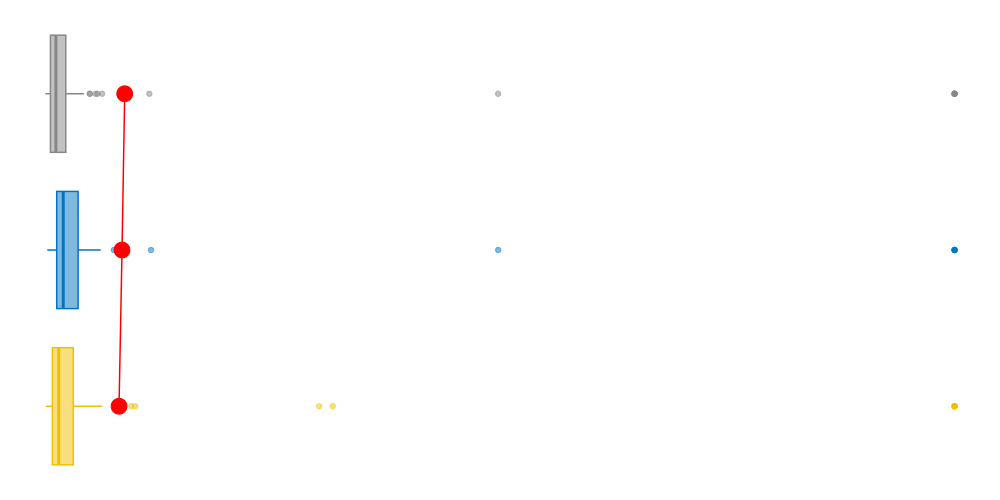

34%

0%

0%

39%

27%

Timing above threshold

mean timing above 10

1%

−0%

5%

4%

5%

9%

8%

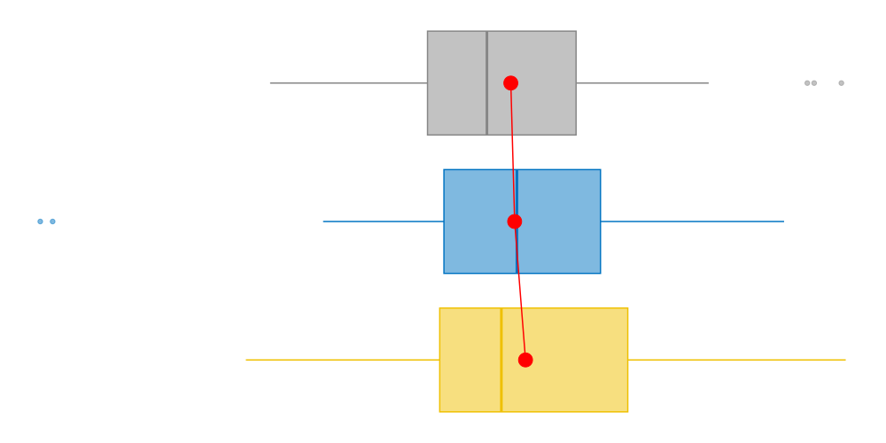

11%

6%

12%

38%

32%

L10

brightest 10h offset

1%

−0%

5%

7%

6%

6%

8%

11%

20%

18%

19%

32%

L10

brightest 10h midpoint

2%

−0%

7%

9%

8%

9%

11%

11%

20%

18%

19%

32%

L10

brightest 10h onset

2%

−0%

11%

15%

14%

14%

18%

11%

20%

18%

19%

32%

L10

brightest 10h mean

1%

3%

38%

17%

17%

41%

21%

[38 more figures not shown]

1%

8%

9%

55%

26%

Analysis based on the Akuffo et al. dataset, 2025 (https://github.com/MeLiDosProject/AkuffoEtAl_Dataset_2025)

No p-value correction was applied, as a significant difference is considered the more undesirable outcome, and should thus not be penalized

<sup>1</sup> Reduced model complexities are indicated by missing random effects

```r
metric_results <-
metric_results |>
  ungroup() |>
  # dplyr::filter(signif_chest) |>
  mutate(signif = case_when(signif_chest & signif_wrist ~ "A",
                            signif_chest ~ "B",
                            signif_wrist ~ "C",
                            .default = "D") |>
           factor(levels = c("D", "B", "C", "A"),
                  c("None differ significantly from head:",
                    "Only chest differs significantly from head position:",
                    "Only wrist differs significantly from head position:",
                    "Both differ significantly from head position:"))
         ) |>
  group_by(signif) |>
    arrange(.by_group = TRUE, (error_chest + error_wrist)/2)


overview <- function(data) {
  data |>
    mutate(position = fct_relevel(position, c("chest", "head", "wrist"))) |>
    ggplot(aes(x=position, y = value)) +
  geom_boxplot(aes(col = position, fill = position), alpha = 0.5) +
    stat_summary(geom = "point", col = "red", fun = mean, size = 5) +
    geom_path(data = \(x) x |>
                group_by(position) |>
                summarize(value = mean(value)),
              col = "red",
              aes(group = 1)) +
  scale_color_manual(values = colors) +
    guides(fill = "none", color = "none") +
  scale_fill_manual(values = colors) +
    theme_void() +
    coord_flip()
}

table <-
metric_results|>
  group_by(signif) |>
  select(family, signif, metric, error_chest, error_wrist,
         Id_sd, chest_sd, wrist_sd, Date_sd, Residual_sd,
         Id_contrib, chest_contrib, wrist_contrib, Date_contrib, Residual_contrib,
         Plot = data
         ) |>
  gt(rowname_col = "family") |>
  fmt_percent(decimals = 0) |>
  tab_spanner(label = "Intraclass correlation (ICC)", columns = contains("_contrib")) |>
  tab_spanner(label = "Standard deviation (SD)", columns = contains("_sd")) |>
  tab_spanner(label = "Mean error", columns = contains("error_")) |>
  cols_label_with(fn = \(x) str_remove(x, "_contrib")) |>
  cols_label_with(fn = \(x) str_remove(x, "_sd")) |>
  cols_label(contains("chest") ~ "Chest",
             contains("wrist") ~ "Wrist") |>
  fmt(metric, fns = \(x) str_replace_all(x, "_", " ")) |>
  fmt_missing() |>
  gt_add_divider(c(error_wrist, Plot), weight = "0.5 px") |>
  tab_header("Summary of significant and non-significant differences in metrics",
             md(glue("<b style = 'color:{colors['head']}'>Reference level: head</b>; random intercepts for Id and Date, random slopes for wearing position"))) |>
  tab_footnote("Analysis based on the Akuffo et al. dataset, 2025 (https://github.com/MeLiDosProject/AkuffoEtAl_Dataset_2025)") |>
  tab_footnote("No p-value correction was applied, as a significant difference is considered the more undesirable outcome, and should thus not be penalized") |>
  tab_footnote("Reduced model complexities are indicated by missing random effects",
               locations =
                 cells_column_labels(c(chest_contrib, wrist_contrib, Date_contrib,
                                       chest_sd, wrist_sd, Date_sd))) |>
  cols_move(Plot, Residual_sd)|>
  summary_rows(columns = -c(metric,Plot),
    fns = list("Median (abs)" ~ median(abs(.), na.rm = TRUE)),
                     fmt = ~ fmt_percent(., decimals = 0),
                     side = "top", missing_text = "Boxplot"
  ) |>
  grand_summary_rows(columns = -c(metric,Plot),
                     fns = list("Grand minimum (abs)" ~ min(abs(.), na.rm = TRUE),
                                "Grand median (abs)" ~ median(abs(.), na.rm = TRUE),
                                "Grand maximum (abs)" ~ max(abs(.), na.rm = TRUE)),
                     fmt = ~ fmt_percent(., decimals = 0),
                     missing_text = "",
                     side = "top") |>
  tab_style(style = cell_text(color = colors["chest"]),
            locations = list(cells_column_labels(contains("chest")),
                             cells_body(contains("chest")))) |>
  tab_style(style = cell_text(color = colors["wrist"]),
            locations = list(cells_column_labels(contains("wrist")),
                             cells_body(contains("wrist")))) |>
  tab_style(style = cell_fill(color = "grey90"),
            locations = list(cells_grand_summary(), cells_stub_grand_summary())) |>
  tab_style(style = cell_fill(color = "grey95"),
            locations = list(cells_summary(), cells_stub_summary())) |>
    cols_label(Plot = "Boxplot", metric = "Metric") %>%
    text_transform(locations = cells_body(Plot),
                   fn = \(x) {
                       gt::ggplot_image(
                         {
                           metric_results$data %>%
                             map(overview)
                         },
                         height = gt::px(50), aspect_ratio = 2
                       )
                   })
table
```

```r
gtsave(table, "../output/tables/Table_1.png", vwidth = 1500)
```

```
file:////var/folders/9p/326_k3kx43qbn_cyl1rqfhb00000gn/T//RtmphTPPZm/file1132947ba3fc8.html screenshot completed
```

```r
gtsave(table, "../output/tables/Table_1.html", inline_css = TRUE)
```

The final plot shows the distribution of (absolute) error values within a range of 0-100%. Larger values are excluded for visibility.

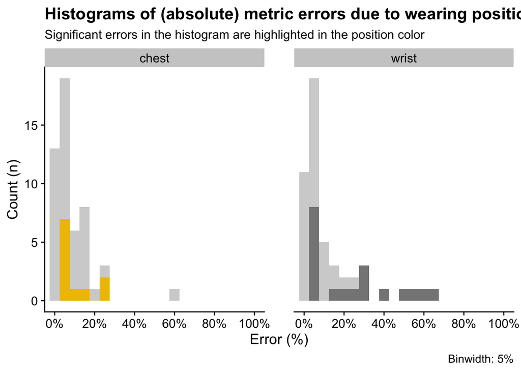

```r
metric_results |>
  ungroup() |>
  select(metric, error_chest, signif_chest, chest_sd,
         error_wrist, signif_wrist, wrist_sd) |>
  rename(sd_chest = chest_sd, sd_wrist = wrist_sd) |>
  pivot_longer(cols =
                 c(error_chest, error_wrist, signif_chest, signif_wrist,
                   sd_chest, sd_wrist),
               names_sep = "_", names_to = c(".value", "position")) |>
  ggplot(aes(x = abs(error))) +
    geom_histogram(binwidth = 0.05, aes(fill = position)) +
    facet_wrap(~position) +
  scale_fill_manual(values = colors) +
  scale_x_continuous(labels = scales::label_percent(accuracy = 1),
                     breaks = seq(0, 1, by = 0.2)) +
  theme_cowplot() +
  coord_cartesian(xlim = c(0,1)) +
  guides(fill = "none") +
  labs(caption = "Binwidth: 5%",
       title = "Histograms of (absolute) metric errors due to wearing position",
       subtitle = "Significant errors in the histogram are highlighted in the position color",
       y = "Count (n)", x = "Error (%)") +
  theme(panel.spacing = unit(2, "lines")) +
  gghighlight(signif, use_group_by = FALSE,
              label_key = metric, calculate_per_facet = TRUE)
```

```r
    # geom_histogram(aes(x = sd*1.96),
    #              color = NA, alpha = 0.2, binwidth = 0.05)

ggsave("../output/figures/Figure_4.pdf", height = 5, width = 8)
```

Interestingly, both chest- and wrist position seem to err on the higher side, at least overall:

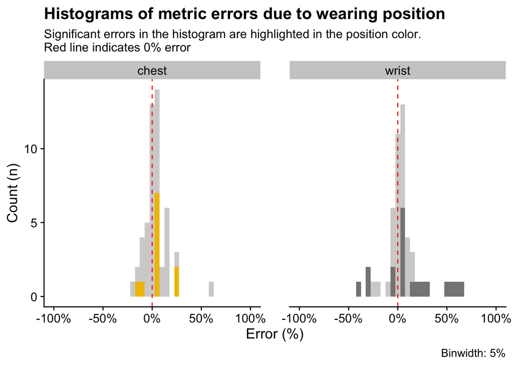

```r
metric_results |>
  ungroup() |>
  select(metric, error_chest, signif_chest, chest_sd,
         error_wrist, signif_wrist, wrist_sd) |>
  rename(sd_chest = chest_sd, sd_wrist = wrist_sd) |>
  pivot_longer(cols =
                 c(error_chest, error_wrist, signif_chest, signif_wrist,
                   sd_chest, sd_wrist),
               names_sep = "_", names_to = c(".value", "position")) |>
  ggplot(aes(x = error)) +
    geom_histogram(binwidth = 0.05, aes(fill = position)) +
    facet_wrap(~position) +
  scale_fill_manual(values = colors) +
  scale_x_continuous(labels = scales::label_percent(accuracy = 1)) +
  theme_cowplot() +
  coord_cartesian(xlim = c(-1,1)) +
  guides(fill = "none") +
  labs(caption = "Binwidth: 5%",
       title = "Histograms of metric errors due to wearing position",
       subtitle = "Significant errors in the histogram are highlighted in the position color.\nRed line indicates 0% error",
       y = "Count (n)", x = "Error (%)") +
  theme(panel.spacing = unit(2, "lines")) +
  gghighlight(signif, use_group_by = FALSE,
              label_key = metric, calculate_per_facet = TRUE) +
  geom_vline(aes(xintercept = 0), col = "red", linetype = "dashed")
```